# Homework 1 (Alejandro Hernandez Segura)

This is a simple example showing a social network dataset and some operations performed on it in R. For Homework 1, you just have to get this markdown file to run.

## Setup

The “sand” package loads igraph and all the associated packages.

```
library("sand")
```

## The Data

Next we need to load the data file. This file can be obtained from the Pajek website or from D2L.

```r
setwd("C:/Users/alexherseg/Documents/School/2_Spring_14_15/csc495/hwk1")
dtp <- read.graph("dining.net", format="pajek")
dtp
```

```
## IGRAPH D-W- 26 52 --
## + attr: id (v/c), x (v/n), y (v/n), z (v/n), weight (e/n)
```

Find the names associated with each vertex.

```r
list.vertex.attributes(dtp)
```

```
## [1] "id" "x"  "y"  "z"
```

```r
V(dtp)$id
```

```
##  [1] "Ada"     "Cora"    "Louise"  "Jean"    "Helen"   "Martha"  "Alice"
##  [8] "Robin"   "Marion"  "Maxine"  "Lena"    "Hazel"   "Hilda"   "Frances"
## [15] "Eva"     "Ruth"    "Edna"    "Adele"   "Jane"    "Anna"    "Mary"
## [22] "Betty"   "Ella"    "Ellen"   "Laura"   "Irene"
```

Let’s plot with the labels. I use an expansion factor of 0.6 for the arrows because otherwise they are too huge:

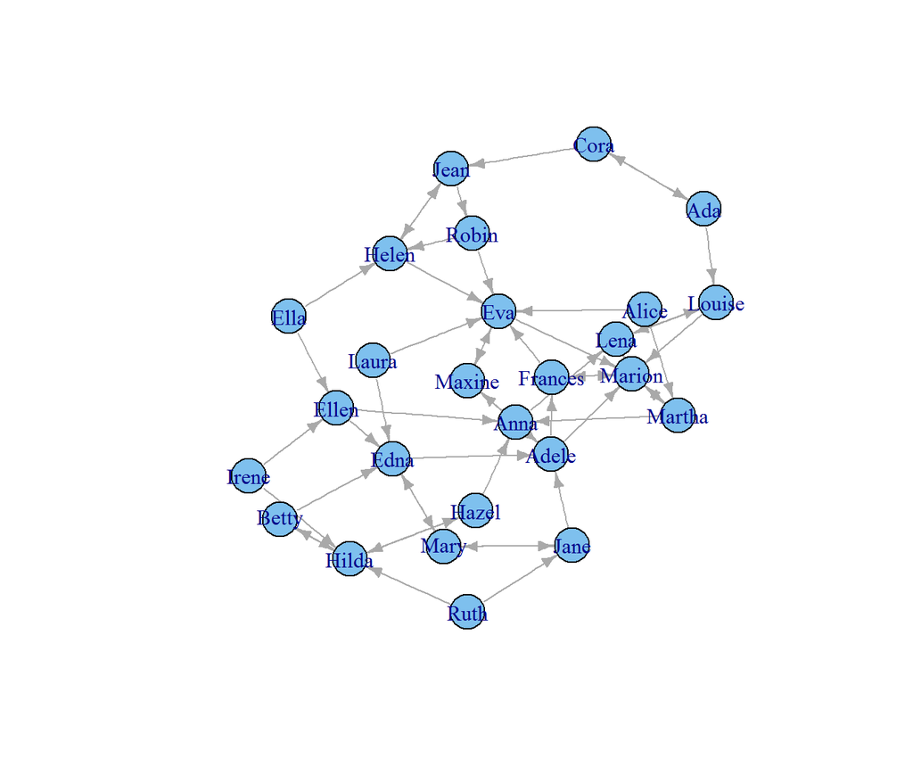

```r
plot(dtp, vertex.label=V(dtp)$id, edge.arrow.size=0.6,
     layout=layout.kamada.kawai)
```

## Sizing by Degree

The degree of nodes is important. In this network, in-degree is important because it shows what nodes are popular among their peers. Because of the way the data was collected, all nodes have the same out-degree (2).

```r
dtp.deg <- degree(dtp, mode="in")

table(dtp.deg)
```

```
## dtp.deg
## 0 1 2 3 4 6
## 5 5 9 3 2 2
```

Try plotting again, with the vertices sized by in-degree.

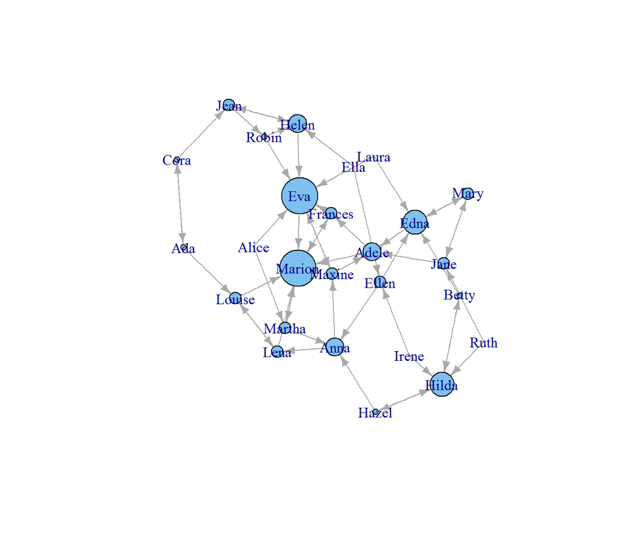

```r
plot(dtp, vertex.label=V(dtp)$id, edge.arrow.size=0.6,
     layout=layout.kamada.kawai, vertex.size=dtp.deg*4)
```

The big vertices are too big and the small ones, too small. (Some have in-degree 0.)

How about multiplying by 2 and adding 5. Then the range will be 5 to 17 instead of 0 to 24.

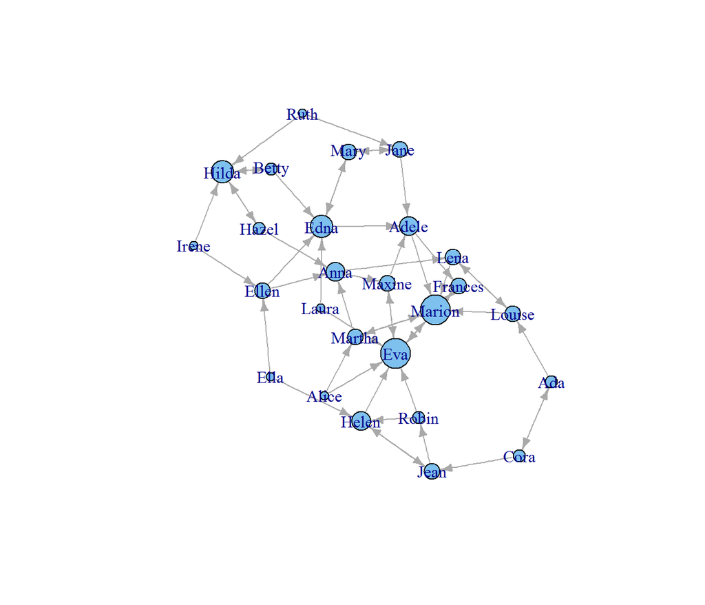

```r
dtp.size <- dtp.deg * 2 + 5

plot(dtp, vertex.label=V(dtp)$id, edge.arrow.size=0.6,
     layout=layout.kamada.kawai, vertex.size=dtp.size)
```

## Edge Information

Put edge weights into a vector

```r
list.edge.attributes(dtp)
```

```
## [1] "weight"
```

```r
dtp.pref <- E(dtp)$weight
table(dtp.pref)
```

```
## dtp.pref
##  1  2
## 26 26
```

The “1” attribute means first choice and “2” means second choice. So, really, we want to emphasize the “1” edges and de-emphasizes the “2” edges. We can accomplish this with a calculation 4/wt^2. This means that second choice edges will have weight 1 and first choice edges weight 4.

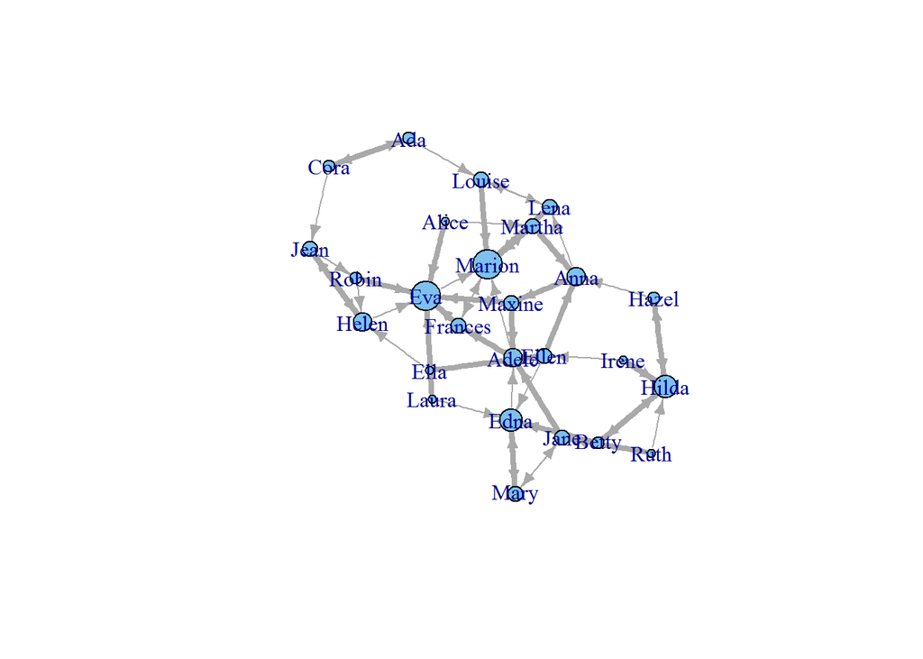

```r
dtp.wt <- 4 / (E(dtp)$weight*E(dtp)$weight)

plot(dtp, vertex.label=V(dtp)$id, edge.arrow.size=0.6,
     layout=layout.kamada.kawai, vertex.size=dtp.size,
     edge.width=dtp.wt)
```

## Coordinate Matrix

It turns out that the authors included x and y positions for the vertices. Let’s use those.

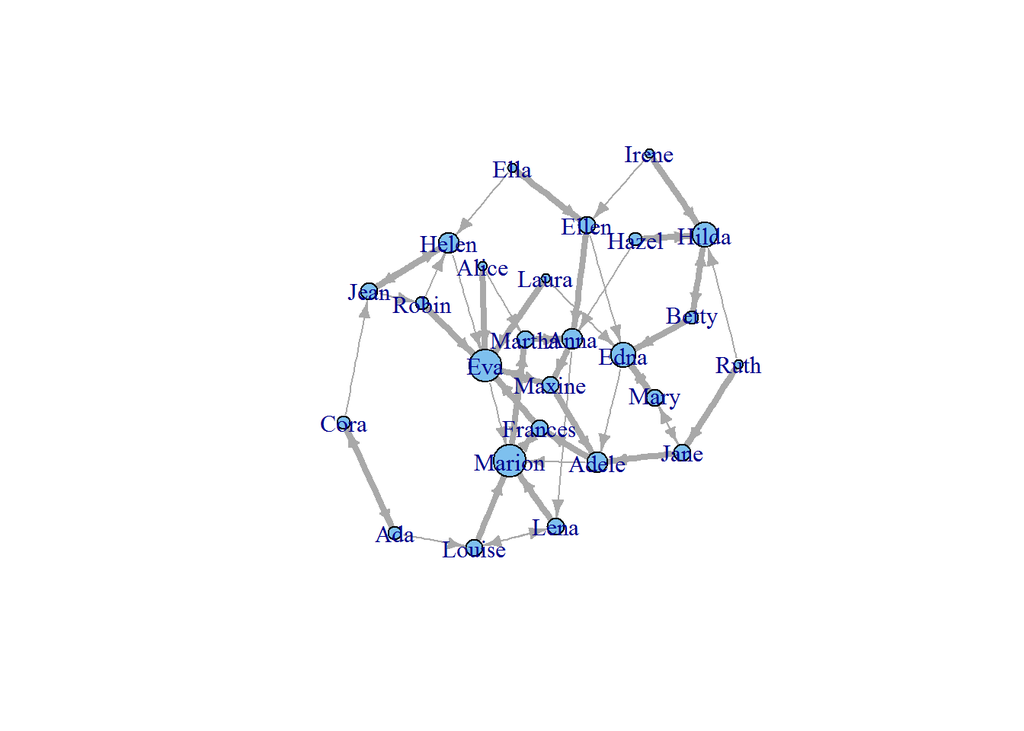

```r
xc <- V(dtp)$"x"*2.0
yc <- V(dtp)$"y"*2.0
# Put X and y coordinates together into a coordinate matrix.
mcoord <- cbind(xc, yc)

plot(dtp, vertex.label=V(dtp)$id, edge.arrow.size=0.6,
     layout=mcoord, vertex.size=dtp.size,
     edge.width=dtp.wt)
```

Clustering ————————————————

Finally, let’s do some clustering. We’ll convert to an undirected graph, because most clustering algorithms are developed for that kind of graph.

```r
dtp.un <- as.undirected(dtp, mode="collapse",
                        edge.attr.comb="ignore")

dtp.com <- walktrap.community(dtp.un)
dtp.com
```

```
## Graph community structure calculated with the walktrap algorithm
## Number of communities (best split): 3
## Modularity (best split): 0.4036281
## Membership vector:
##  [1] 1 1 3 1 1 3 3 1 3 3 3 2 2 3 3 2 2 3 2 3 2 2 2 2 2 2
```

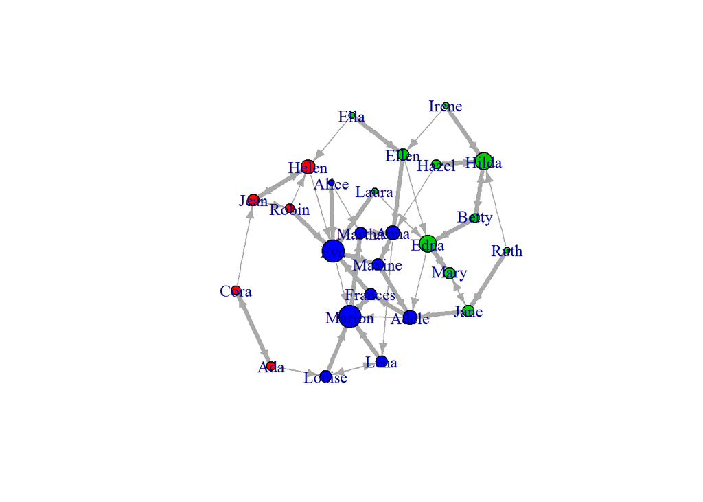

```r
# Get the membership vector
dtp.vec <- dtp.com$membership
# Use it to color the vertices
plot(dtp, vertex.label=V(dtp)$id, edge.arrow.size=0.6,
     layout=mcoord, vertex.size=dtp.size,
     vertex.color=dtp.vec+1,
     edge.width=dtp.wt)
```

Not bad, but probably we would do better if we took the edge weights and directions into account.